# Global Youtube Statistics 2023

# 2) Null hypothesis and Alternate Hypothesis

H_O : = variances are equal ; H_1 : = Variances are not equal(two-sided test).

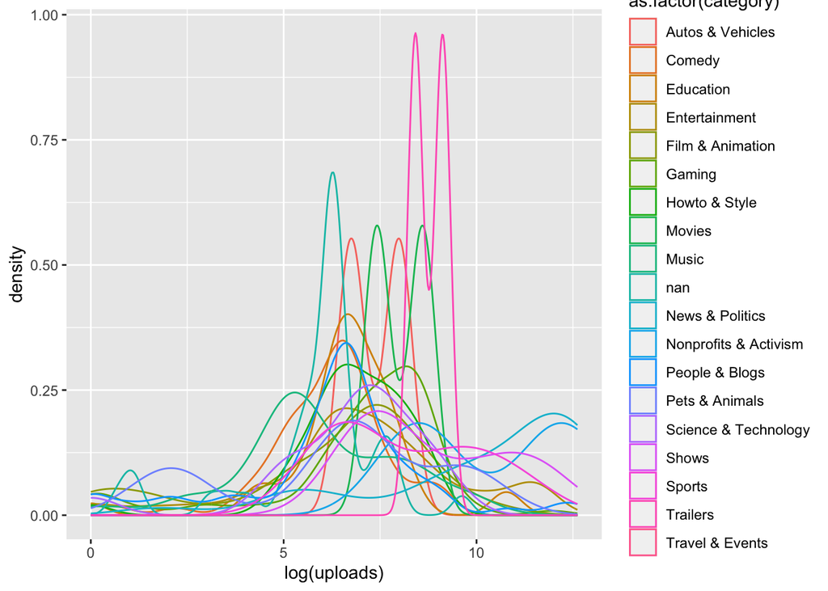

```r
# Reference distribution
library(ggplot2)

ggplot(data = indata) +
  geom_density(mapping = aes(x = log(uploads), color = as.factor(category)))
```

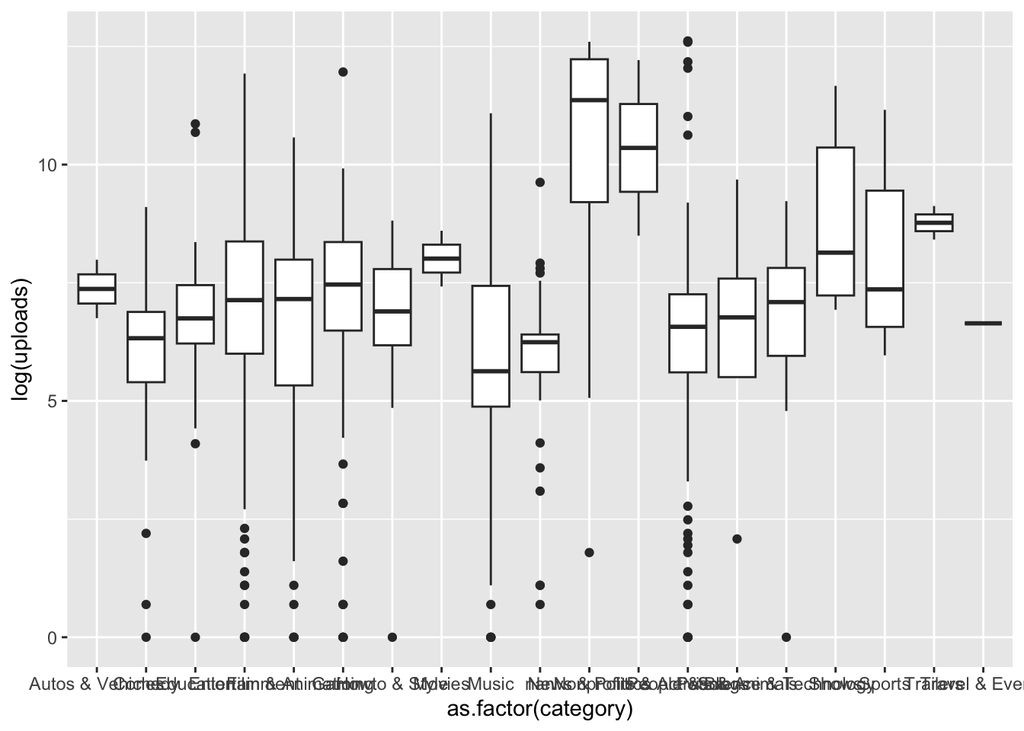

```r
ggplot(data = indata) +
  geom_boxplot(mapping = aes(x = as.factor(category), y = log(uploads)))
```

```r
data <- data.frame(
  category = c("Autos & Vehicles", "Entertainment", "Howto & Style", "nan", "People & Blogs", "Shows", "Travel & Events", "Comedy", "Film & Animation", "Movies", "News & Politics", "Pets & Animals", "Sports", "Education", "Gaming", "Music", "Nonprofits & Activism", "Science & Technology", "Trailers")
)
data$category <- as.factor(data$category)
str(data)
```

```
## 'data.frame':    19 obs. of  1 variable:
##  $ category: Factor w/ 19 levels "Autos & Vehicles",..: 1 4 7 10 13 16 19 2 5 8 ...
```

```r
indata$category <- as.factor(indata$category)
summary(indata$category)
```

```
##      Autos & Vehicles                Comedy             Education
##                     2                    69                    45
##         Entertainment      Film & Animation                Gaming
##                   241                    46                    94
##         Howto & Style                Movies                 Music
##                    40                     2                   202
##                   nan       News & Politics Nonprofits & Activism
##                    46                    26                     2
##        People & Blogs        Pets & Animals  Science & Technology
##                   132                     4                    17
##                 Shows                Sports              Trailers
##                    13                    11                     2
##       Travel & Events
##                     1
```

```r
sum(is.na(indata$category))
```

```
## [1] 0
```

```r
# Test Statistic (F test)
Entertainment <- indata[indata$category == "Entertainment", "uploads"]
Music <- indata[indata$category == "Music", "uploads"]

# Checking for missing values in the uploads column
sum(is.na(Entertainment))
```

```
## [1] 0
```

```r
sum(is.na(Music))
```

```
## [1] 0
```

```r
var.test(log(Entertainment[!is.na(Entertainment)]), log(Music[!is.na(Music)]))
```

```
##
##  F test to compare two variances
##
## data:  log(Entertainment[!is.na(Entertainment)]) and log(Music[!is.na(Music)])
## F = 1.4324, num df = 228, denom df = 194, p-value = 0.01002
## alternative hypothesis: true ratio of variances is not equal to 1
## 95 percent confidence interval:
##  1.090179 1.876301
## sample estimates:
## ratio of variances
##           1.432363
```

# Conclusion

** we reject null hypothesis as p-value is less than the level of significance.**

# LINEAR REGRESSION

ASSUMPTIONS FOR LINEAR REGRESSION: 1) Independent and identically distributed 2)Mean shiuld be equal to zero 3)Constant variance.

```r
cor(indata[ , c('rank','subscribers','uploads','video.views')])
```

```
##                    rank subscribers     uploads video.views
## rank         1.00000000 -0.64060828 -0.05103565  -0.4533634
## subscribers -0.64060828  1.00000000  0.07713566   0.7509576
## uploads     -0.05103565  0.07713566  1.00000000   0.1659277
## video.views -0.45336341  0.75095762  0.16592770   1.0000000
```

** It shows the correlation between rank, subscribers, uploads, video.views. **

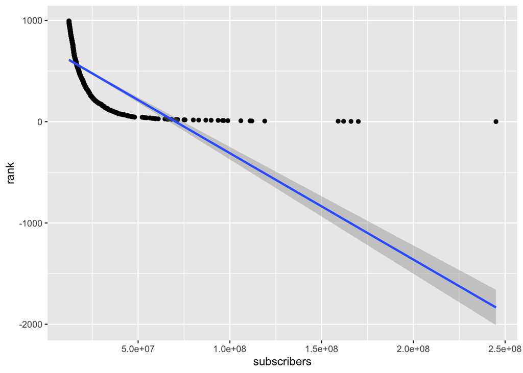

```r
indata %>%
  ggplot(aes(x = subscribers, y = rank)) +
  geom_point() + geom_smooth(method = 'lm')
```

** There is a negative correlation between subscribers and rank, if we look at the confidence interval we can identify the outliers **

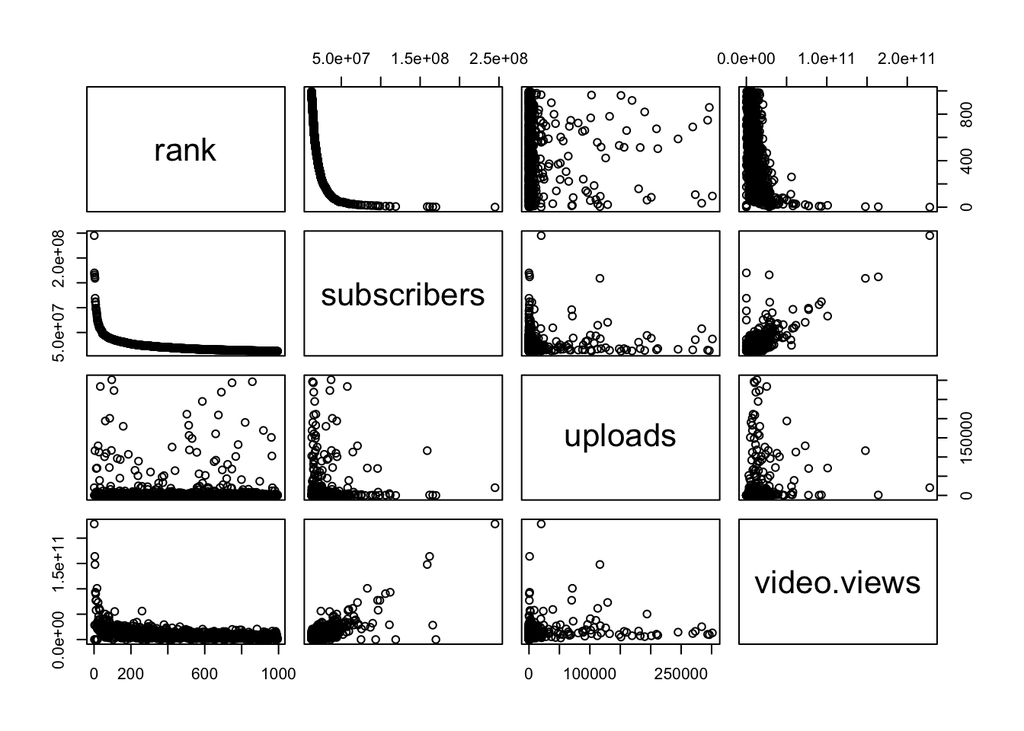

```r
columns <- c('rank','subscribers','uploads','video.views')
pairs(indata[, columns])
```

** There might be a correlation between regressors, and there is a relationship between regressors and the response. Here, rank and subscribers have negative relationship, while video.views and subscribers have a positive relationship. **

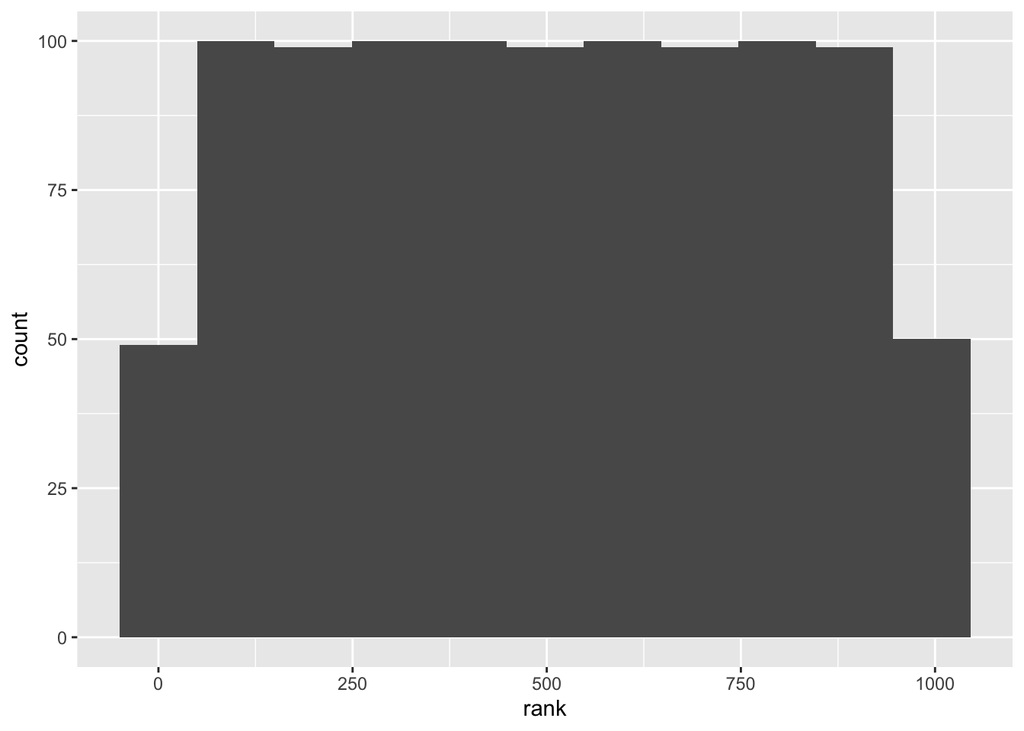

```r
indata %>%
  ggplot(aes(x = rank)) +
  geom_histogram(binwidth = function(x) 2 * IQR(x) / (length(x)^(1/3)))
```

```r
(lm.fit <- lm(rank ~ subscribers + uploads + video.views, data = indata))
```

```
##
## Call:
## lm(formula = rank ~ subscribers + uploads + video.views, data = indata)
##
## Coefficients:
## (Intercept)  subscribers      uploads  video.views
##   7.437e+02   -1.130e-05   -7.380e-05    1.338e-09
```

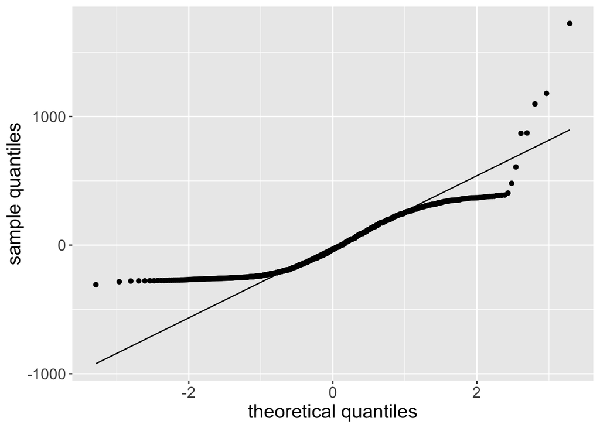

```r
#residual plot
fit_residuals <- lm.fit$residuals %>% as.data.frame()
  fit_residuals %>%
  ggplot (aes(sample = lm.fit$residuals)) + stat_qq(distribution = stats :: qnorm) +
  stat_qq_line() + labs( y = "sample quantiles", x = "theoretical quantiles")  +
  theme(text = element_text(size = 16))
```

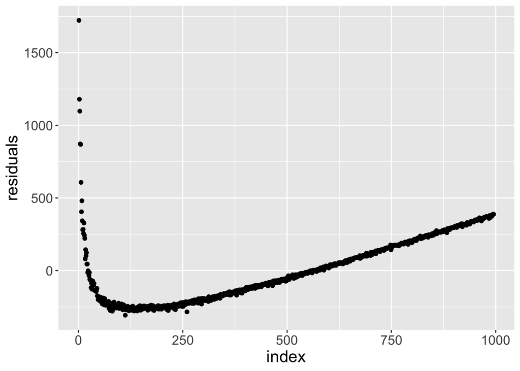

```r
fit_residuals %>%
  ggplot(aes(y = lm.fit$residuals, x = 1:nrow(fit_residuals))) +
  geom_point() + labs(y = "residuals", x = "index") +
  theme(text = element_text(size= 16))
```

```r
summary(lm.fit)
```

```
##
## Call:
## lm(formula = rank ~ subscribers + uploads + video.views, data = indata)
##
## Residuals:
##     Min      1Q  Median      3Q     Max
## -307.64 -199.02  -34.17  173.76 1722.73
##
## Coefficients:
##               Estimate Std. Error t value Pr(>|t|)
## (Intercept)  7.437e+02  1.184e+01  62.812   <2e-16 ***
## subscribers -1.130e-05  6.063e-07 -18.640   <2e-16 ***
## uploads     -7.380e-05  2.084e-04  -0.354   0.7233
## video.views  1.338e-09  7.614e-10   1.758   0.0791 .
## ---
## Signif. codes:  0 '***' 0.001 '**' 0.01 '*' 0.05 '.' 0.1 ' ' 1
##
## Residual standard error: 220.7 on 991 degrees of freedom
## Multiple R-squared:  0.4122, Adjusted R-squared:  0.4104
## F-statistic: 231.7 on 3 and 991 DF,  p-value: < 2.2e-16
```

** Here, we are testing whether the coefficient of the regressors is statistically significant or not. Uploads and video.views are not statistically significant at 0.05 level. No relationship or contribution from them is evident, as their effects may be masked by other correlated regressors. It is necessary to reduce their correlation to extract the relevant regressors. **

```r
(lm.fit2 <- lm(rank ~ subscribers, data = indata))
```

```
##
## Call:
## lm(formula = rank ~ subscribers, data = indata)
##
## Coefficients:
## (Intercept)  subscribers
##   7.394e+02   -1.050e-05
```

```r
summary(lm.fit2)
```

```
##
## Call:
## lm(formula = rank ~ subscribers, data = indata)
##
## Residuals:
##     Min      1Q  Median      3Q     Max
## -265.23 -199.84  -33.85  173.35 1835.09
##
## Coefficients:
##               Estimate Std. Error t value Pr(>|t|)
## (Intercept)  7.394e+02  1.155e+01   64.04   <2e-16 ***
## subscribers -1.050e-05  3.996e-07  -26.29   <2e-16 ***
## ---
## Signif. codes:  0 '***' 0.001 '**' 0.01 '*' 0.05 '.' 0.1 ' ' 1
##
## Residual standard error: 220.8 on 993 degrees of freedom
## Multiple R-squared:  0.4104, Adjusted R-squared:  0.4098
## F-statistic: 691.1 on 1 and 993 DF,  p-value: < 2.2e-16
```

** We want P value to be small. By conducting the hypothesis test each line, we observe the distribution that illustrates the relation between rank(response) and subscribers(regressors). **

# CONCLUSION

** The analysis on the ‘Global YouTube Statistics 2023’ dataset concentrates on the rank, number of subscribers, and category columns. The summary statistics and data visualization of categories, subscribers, rank, etc., provide better information for enthusiastic young YouTubers considering You Tube channels as their career field. The stakeholders can acknowledge how subscriber distribution across various categories helps them in making decisions.

I cannot perform Principal Component Analysis(PCA) because the variables I chose have a higher number of categorical variables than the numeric ones. **